# R Notebook

# Statistics I Homework Ch5_Textbook

## 5.3

# Statistics I Homework Ch5_A1

### data pre-processing:

```r
data <- read.csv("sampling.csv" ,header = 1)
```

## 1

將column指向目標Fruit and Vegetables，算出mean, population variance和adjusted population variance，前兩者有函式可直接算出，而adjusted population variance則是用母體的變異數*n/(n - 1)

```r
columnD <- data$Fruit.and.Vegetables
mean_p =mean(columnD)
var_p =var(columnD)
var_s =var(columnD)*24000/23999
cat(mean_p,'\n',var_p,'\n',var_s)
```

```
3.644421
 0.7164121
 0.7164419
```

mean:3.644421 population variance:0.7164121 adjusted population variance:0.7164419

## 2

先設好seed，用column A的編號來抽隨機變數，再用對應的column D去算mean跟variance

```r
set.seed(32535)
columnA <- data$Frame.No.
s1 = sample(columnA,240)
resultofs1 = data[s1,]
m1 = mean(resultofs1$Fruit.and.Vegetables)
var1 = var(resultofs1$Fruit.and.Vegetables)
cat(m1,"\n",var1)
```

```
3.567917
 0.7642802
```

mean:3.567917 variance:0.7642802

## 3

```r
abs(mean_p-m1)
```

```
[1] 0.07650417
```

```r
abs(var_p-var1)
```

```
[1] 0.0478681
```

```r
abs(var_s-var1)
```

```
[1] 0.04783825
```

## 4

設好seed並且開三個陣列分別存放與母體mean差距、與population variance差距、與adjusted population variance的差距。將每次的差距紀錄下來，最後算出三者的RMSE。

```r
set.seed(1118)
ssize = 240
nrun = 1000
err_m_all = vector(mode = "numeric", length = nrun)
err_v_p_all = vector(mode = "numeric", length = nrun)
err_v_s_all = vector(mode = "numeric", length = nrun)
for(runid in 1:nrun) {
    s2 = sample(columnA, ssize)
    resultofs2 = data[s2,]
    m2 = mean(resultofs2$Fruit.and.Vegetables)
    var2 = var(resultofs2$Fruit.and.Vegetables)
    #cat(m2, "\n")
    err_m = (mean_p - m2)^2
    err_v_p = (var_p - var2)^2
    err_v_s = (var_s - var2)^2
    err_m_all[runid] = err_m
    err_v_p_all[runid] = err_v_p
    err_v_s_all[runid] = err_v_s
}
avg_err_m = sqrt(mean(err_m_all))
avg_err_v_p = sqrt(mean(err_v_p_all))
avg_err_v_s = sqrt(mean(err_v_s_all))
cat("Average sampling error (mean)", avg_err_m, "\n")
```

```
Average sampling error (mean) 0.05383188
```

```r
cat("Average sampling error (varaiance_p)", avg_err_v_p, "\n")
```

```
Average sampling error (varaiance_p) 0.06491478
```

```r
cat("Average sampling error (varaiance_s)", avg_err_v_s, "\n")
```

```
Average sampling error (varaiance_s) 0.06491449
```

## 5

```r
ssize = vector(mode = "numeric", length = 11)
mofsize = vector(mode = "numeric", length = 11)
varofsize = vector(mode = "numeric", length = 11)
ssize[1] = 10
ssize[2] = 20
ssize[3] = 40
ssize[4] = 80
ssize[5] = 160
ssize[6] = 320
ssize[7] = 640
ssize[8] = 1280
ssize[9] = 2560
ssize[10] = 5120
ssize[11] = 12800
nrun = 200
nsize = 1
mm= vector(mode = "numeric", length = nrun)
for(runid in 1:11) {
  for(runid in 1:nrun) {
    ss = sample(columnA, ssize[nsize],replace = TRUE)
    resultofss = data[ss,]
    mm[runid] = mean(resultofss$Fruit.and.Vegetables)
  }
  mofsize[nsize] = mean(mm)
  varofsize[nsize] = var(mm)*ssize[nsize]/(ssize[nsize]-1)
  cat("size =",ssize[nsize],"mean = ",mofsize[nsize],"unbiased var = ",varofsize[nsize],"\n")
  nsize = nsize + 1
}
```

```
size = 10 mean =  3.6482 unbiased var =  0.09221749
size = 20 mean =  3.6398 unbiased var =  0.03896769
size = 40 mean =  3.651512 unbiased var =  0.01941012
size = 80 mean =  3.646594 unbiased var =  0.008875293
size = 160 mean =  3.641341 unbiased var =  0.003758223
size = 320 mean =  3.645802 unbiased var =  0.002506782
size = 640 mean =  3.642236 unbiased var =  0.0009784882
size = 1280 mean =  3.647183 unbiased var =  0.0005637433
size = 2560 mean =  3.643131 unbiased var =  0.0003372577
size = 5120 mean =  3.645702 unbiased var =  0.0001445589
size = 12800 mean =  3.643706 unbiased var =  5.605519e-05
```

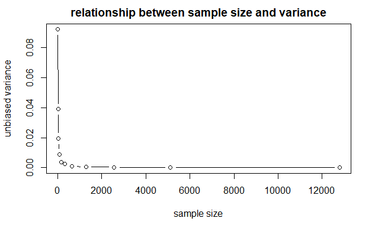

```r
plot(ssize,varofsize,"b",main="relationship between sample size and variance",xlab="sample size",ylab="unbiased variance")
```

```r
#10, 20, 40, 80, 160, 320, 640, 1280, 2560, 5120, 12800
```